# Cross-Validation In-Class Activity - SOLUTIONS

Instructor

2025-10-22

# Learning Objectives

By the end of this activity, you will be able to:

1. Implement different cross-validation methods in R
2. Compare validation set approach vs k-fold cross-validation
3. Perform cross-validation for both regression and classification
4. Use cross-validation with k-NN models
5. Select optimal model complexity using CV results

## Part 1: The Problem with Simple Train-Test Split (10 minutes)

Let’s start by exploring why a simple train-test split can be unreliable.

### Exercise 1.1: Variable Results from Train-Test Split

Using the `Auto` dataset, we’ll fit polynomial models of different degrees and see how much the results vary with different random splits.

```r
# Load the Auto dataset
data(Auto)

# Function to perform one train-test split and return test MSE for different polynomial degrees
single_split_mse <- function(split_seed, max_degree = 8) {
  set.seed(split_seed)

  # 1. Create a random train-test split (use 70% for training)
  n <- nrow(Auto)
  train_indices <- sample(1:n, size = floor(0.7 * n))
  train_data <- Auto[train_indices, ]
  test_data <- Auto[-train_indices, ]

  # 2. For each polynomial degree, fit model and calculate test MSE
  test_mse <- numeric(max_degree)

  for(degree in 1:max_degree) {
    # Fit the model
    model <- lm(mpg ~ poly(horsepower, degree), data = train_data)

    # Make predictions on test data
    predictions <- predict(model, newdata = test_data)

    # Calculate test MSE
    test_mse[degree] <- mean((test_data$mpg - predictions)^2)
  }

  # 3. Return vector of test MSE values
  return(test_mse)
}

# Test the function
test_mse <- single_split_mse(123)
print(test_mse)
```

```
## [1] 21.16809 15.85013 15.92553 16.34708 16.30765 15.91825 15.65640 15.71454
```

Now let’s see how much the results vary:

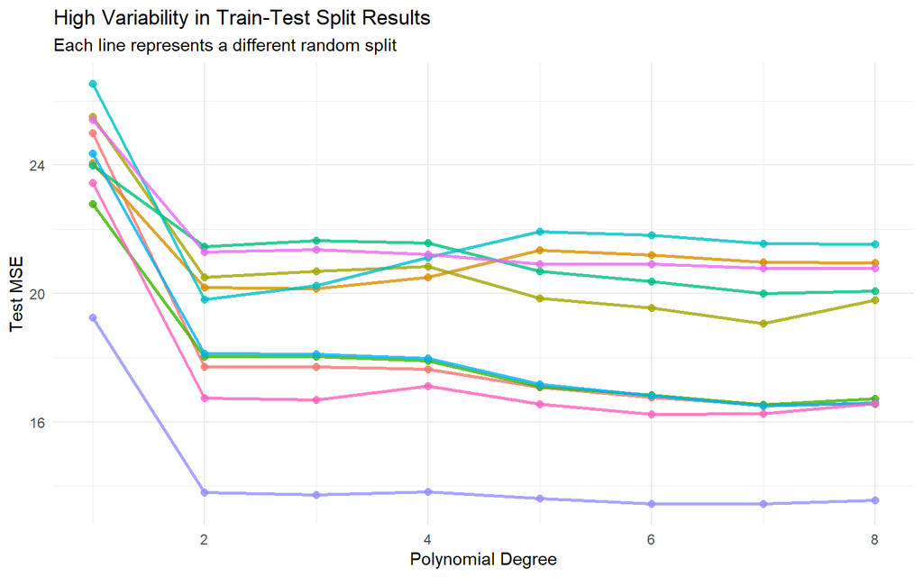

```r
# Try 10 different random splits
n_splits <- 10
degrees <- 1:8
results_matrix <- matrix(NA, nrow = n_splits, ncol = length(degrees))

for(i in 1:n_splits) {
  results_matrix[i, ] <- single_split_mse(i * 10)
}

# Create a plot showing the variability
results_df <- as.data.frame(results_matrix)
colnames(results_df) <- paste("Degree", degrees)
results_df$Split <- 1:n_splits

results_long <- results_df %>%
  pivot_longer(cols = -Split, names_to = "Polynomial_Degree", values_to = "Test_MSE") %>%
  mutate(Degree = as.numeric(str_extract(Polynomial_Degree, "\\d+")))

ggplot(results_long, aes(x = Degree, y = Test_MSE, group = Split, color = factor(Split))) +
  geom_line(alpha = 0.8, size = 1) +
  geom_point(alpha = 0.8, size = 2) +
  labs(title = "High Variability in Train-Test Split Results",
       subtitle = "Each line represents a different random split",
       x = "Polynomial Degree",
       y = "Test MSE") +
  theme_minimal() +
  theme(legend.position = "none")
```

**Question 1.1**: What do you notice about the variability? Which polynomial degree would you choose as “best” if you only did one split?

## Part 2: k-Fold Cross-Validation for Regression (10 minutes)

Now let’s use k-fold cross-validation to get more stable results.

### Exercise 2.1: Implementing k-Fold CV

```r
# Function to perform k-fold CV for polynomial regression
polynomial_cv <- function(data, max_degree = 8, k = 10) {
  cv_errors <- numeric(max_degree)

  for(degree in 1:max_degree) {
    # Fit a glm model
    model <- glm(mpg ~ poly(horsepower, degree), data = data)

    # Use cv.glm() to perform k-fold cross-validation
    cv_result <- cv.glm(data, model, K = k)

    # Store the CV error
    cv_errors[degree] <- cv_result$delta[1]
  }

  return(cv_errors)
}

# Test the function
cv_results <- polynomial_cv(Auto, max_degree = 8, k = 10)
print(cv_results)
```

```
## [1] 24.11633 19.31231 19.48892 19.30271 19.53317 19.09548 19.57409 18.76987
```

### Exercise 2.2: Compare Different k Values

```r
# Compare k = 5, k = 10, and LOOCV
k_values <- c(5, 10, nrow(Auto))  # LOOCV uses n folds
k_names <- c("5-fold", "10-fold", "LOOCV")

# Create a data frame to store results for different k values
cv_comparison <- data.frame()

for(i in 1:length(k_values)) {
  if(k_values[i] == nrow(Auto)) {
    # For LOOCV, don't specify K parameter
    cv_errors <- numeric(8)
    for(degree in 1:8) {
      model <- glm(mpg ~ poly(horsepower, degree), data = Auto)
      cv_result <- cv.glm(Auto, model)  # No K parameter = LOOCV
      cv_errors[degree] <- cv_result$delta[1]
    }
  } else {
    cv_errors <- polynomial_cv(Auto, max_degree = 8, k = k_values[i])
  }

  temp_df <- data.frame(
    Degree = 1:8,
    CV_MSE = cv_errors,
    Method = k_names[i]
  )
  cv_comparison <- rbind(cv_comparison, temp_df)
}
```

Let’s visualize the results:

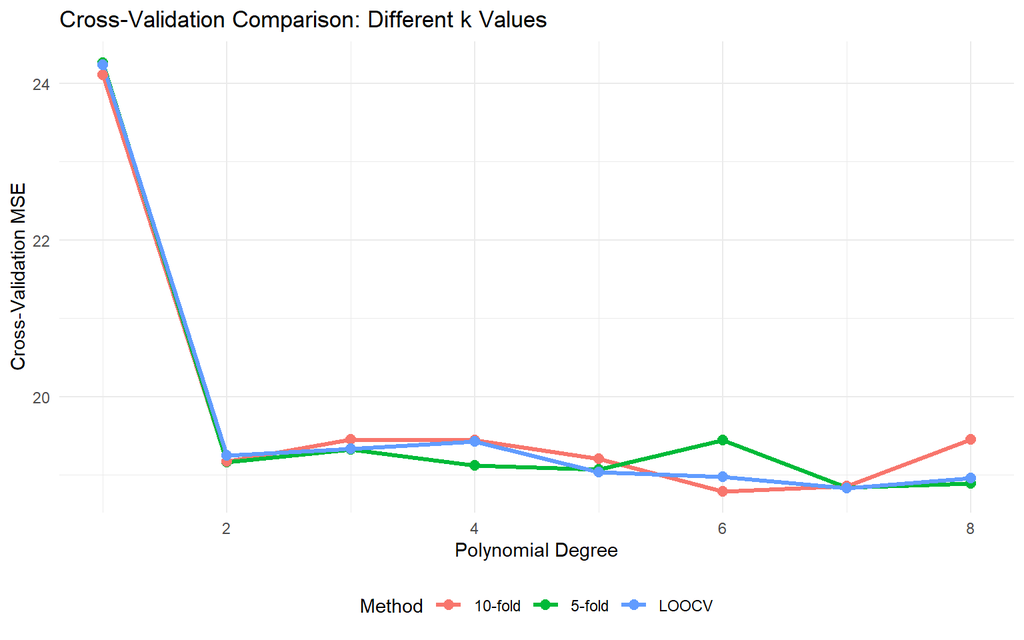

```r
ggplot(cv_comparison, aes(x = Degree, y = CV_MSE, color = Method)) +
  geom_line(size = 1.2) +
  geom_point(size = 2.5) +
  labs(title = "Cross-Validation Comparison: Different k Values",
       x = "Polynomial Degree", y = "Cross-Validation MSE") +
  theme_minimal() +
  theme(legend.position = "bottom")
```

```r
# Store optimal degree for each method
optimal_summary <- cv_comparison %>%
  group_by(Method) %>%
  filter(CV_MSE == min(CV_MSE)) %>%
  summarize(
    Optimal_Degree = Degree,
    Min_CV_MSE = CV_MSE,
    .groups = "drop"
  )

# Get 10-fold results for reference
optimal_degree <- optimal_summary %>%
  filter(Method == "10-fold") %>%
  pull(Optimal_Degree)

optimal_cv_mse <- optimal_summary %>%
  filter(Method == "10-fold") %>%
  pull(Min_CV_MSE)

# Check agreement
methods_agree <- length(unique(optimal_summary$Optimal_Degree)) == 1
optimal_degrees <- paste(optimal_summary$Optimal_Degree, collapse = ", ")
```

**Question 2.1**: Which polynomial degree appears optimal? Do the different CV methods agree?

**Question 2.2**: What are the computational tradeoffs between 5-fold, 10-fold, and LOOCV?

**Answer**:

- **5-fold CV**: Fastest, fits only 5 models per polynomial degree
- **10-fold CV**: Medium speed, fits 10 models per polynomial degree (standard choice)
- **LOOCV**: Slowest, fits n = 392 models per polynomial degree

LOOCV is computationally expensive but provides the least biased estimate of test error. 10-fold CV is typically preferred as it balances computational efficiency with low bias and variance in the error estimate. For this dataset, all three methods give similar results, suggesting 10-fold CV is sufficient.

## Part 3: Cross-Validation for Classification (8 minutes)

Now let’s work with the `Default` dataset for classification.

### Exercise 3.1: CV for Logistic Regression

```r
# Load Default dataset
data(Default)

# Look at the dataset structure
str(Default)
```

```
## 'data.frame':    10000 obs. of  4 variables:
##  $ default: Factor w/ 2 levels "No","Yes": 1 1 1 1 1 1 1 1 1 1 ...
##  $ student: Factor w/ 2 levels "No","Yes": 1 2 1 1 1 2 1 2 1 1 ...
##  $ balance: num  730 817 1074 529 786 ...
##  $ income : num  44362 12106 31767 35704 38463 ...
```

```r
# Define cost function for classification error rate
cost_function <- function(r, pi) {
  # r: actual response (0/1), pi: predicted probabilities
  mean(abs(r - (pi > 0.5)))
}

# Convert default to 0/1 numeric
Default$default_numeric <- as.numeric(Default$default == "Yes")

# Model 1: Linear terms only
model1 <- glm(default_numeric ~ balance + income, data = Default, family = binomial)
cv_error1 <- cv.glm(Default, model1, cost_function, K = 10)
cat("Linear model CV error rate:", cv_error1$delta[1], "\n")
```

```
## Linear model CV error rate: 0.0263
```

```r
# Model 2: Polynomial terms
model2 <- glm(default_numeric ~ poly(balance, 2) + poly(income, 2),
              data = Default, family = binomial)
cv_error2 <- cv.glm(Default, model2, cost_function, K = 10)
cat("Polynomial model CV error rate:", cv_error2$delta[1], "\n")
```

```
## Polynomial model CV error rate: 0.0267
```

```r
# Compare
cat("\nModel comparison:\n")
```

```
##
## Model comparison:
```

```r
cat("Linear model error rate:", round(cv_error1$delta[1], 4), "\n")
```

```
## Linear model error rate: 0.0263
```

```r
cat("Polynomial model error rate:", round(cv_error2$delta[1], 4), "\n")
```

```
## Polynomial model error rate: 0.0267
```

```r
cat("Improvement:", round(cv_error1$delta[1] - cv_error2$delta[1], 4), "\n")
```

```
## Improvement: -4e-04
```

```r
# Store for inline code
linear_error <- cv_error1$delta[1]
poly_error <- cv_error2$delta[1]
improvement <- linear_error - poly_error
```

**Question 3.1**: Which model performs better? Is the improvement substantial?

## Part 4: Cross-Validation with k-NN (12 minutes)

k-NN uses the `class` package which has a built-in LOOCV function `knn.cv()`. Let’s explore this!

### Exercise 4.1: Understanding k-NN Data Preparation

```r
# For k-NN, we need to prepare our data differently
# k-NN requires numeric predictors and works with matrices

# Prepare data for k-NN classification (Default dataset)
knn_data <- Default %>%
  select(balance, income, default) %>%
  na.omit()

# Separate predictors and response
X <- knn_data[, c("balance", "income")]
y <- knn_data$default

# Scale the predictors (important for k-NN!)
X_scaled <- scale(X)

# Look at the data
head(X_scaled)
```

```
##       balance     income
## 1 -0.21882388  0.8131466
## 2 -0.03761405 -1.6054154
## 3  0.49238557 -0.1312057
## 4 -0.63286086  0.1640227
## 5 -0.10278574  0.3708966
## 6  0.17409766 -1.9514229
```

```r
summary(X_scaled)
```

```
##     balance             income
##  Min.   :-1.72700   Min.   :-2.45527
##  1st Qu.:-0.73110   1st Qu.:-0.91301
##  Median :-0.02427   Median : 0.07766
##  Mean   : 0.00000   Mean   : 0.00000
##  3rd Qu.: 0.68415   3rd Qu.: 0.77161
##  Max.   : 3.76037   Max.   : 3.00205
```

```r
table(y)
```

```
## y
##   No  Yes
## 9667  333
```

### Exercise 4.2: k-NN LOOCV with knn.cv()

The `knn.cv()` function automatically performs leave-one-out cross-validation for k-NN classification.

```r
# Test different k values using LOOCV
k_values <- c(1, 3, 5, 7, 9, 11, 15, 21, 31, 41, 51)

# Create a vector to store CV error rates for each k
cv_errors <- numeric(length(k_values))

# For each k value, perform LOOCV
for(i in 1:length(k_values)) {
  k <- k_values[i]

  # Use knn.cv for LOOCV
  predictions <- knn.cv(train = X_scaled, cl = y, k = k)

  # Calculate error rate
  cv_errors[i] <- mean(predictions != y)
}

# Find the optimal k value
best_k <- k_values[which.min(cv_errors)]
cat("Optimal k value:", best_k, "\n")
```

```
## Optimal k value: 41
```

```r
cat("Minimum CV error rate:", min(cv_errors), "\n")
```

```
## Minimum CV error rate: 0.0272
```

```r
# Print results table
results_table <- data.frame(
  k = k_values,
  CV_Error_Rate = round(cv_errors, 4),
  Accuracy = round(1 - cv_errors, 4)
)
print(results_table)
```

```
##     k CV_Error_Rate Accuracy
## 1   1        0.0432   0.9568
## 2   3        0.0340   0.9660
## 3   5        0.0312   0.9688
## 4   7        0.0287   0.9713
## 5   9        0.0283   0.9717
## 6  11        0.0279   0.9721
## 7  15        0.0275   0.9725
## 8  21        0.0273   0.9727
## 9  31        0.0275   0.9725
## 10 41        0.0272   0.9728
## 11 51        0.0277   0.9723
```

Let’s visualize the results:

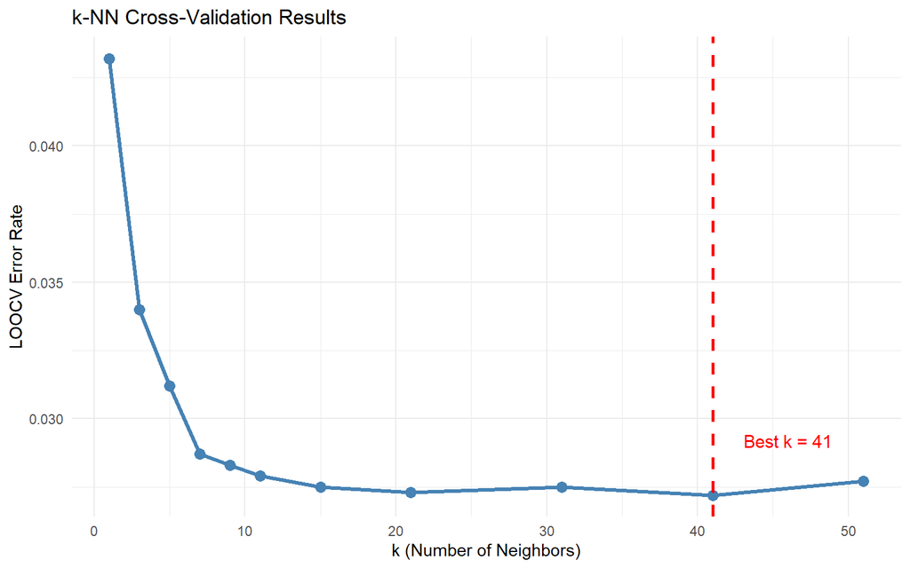

```r
# Create a plot of CV error vs k
knn_results <- data.frame(
  k = k_values,
  cv_error = cv_errors
)

best_k <- k_values[which.min(cv_errors)]

ggplot(knn_results, aes(x = k, y = cv_error)) +
  geom_line(color = "steelblue", size = 1.2) +
  geom_point(color = "steelblue", size = 3) +
  geom_vline(xintercept = best_k, color = "red", linetype = "dashed", size = 1) +
  annotate("text", x = best_k + 5, y = min(cv_errors) + 0.002,
           label = paste("Best k =", best_k), color = "red", size = 4) +
  labs(title = "k-NN Cross-Validation Results",
       x = "k (Number of Neighbors)",
       y = "LOOCV Error Rate") +
  theme_minimal()
```

**Question 4.1**: What’s the optimal k value for k-NN classification? How does this compare to what you might expect?

**Answer**: The optimal k value is 41 neighbors (with a CV error rate of 0.0272 or 97.28% accuracy). This is higher than beginners might expect (they often start with k=3 or k=5). The larger k value helps reduce overfitting and provides more stable predictions. Very small k values (like k=1) perform poorly due to high variance, while very large k values start to perform worse due to oversmoothing.

**Question 4.2**: Why is scaling the predictors (`scale()`) crucial for k-NN but not for linear regression?

**Answer**: k-NN uses distance calculations (Euclidean distance) to find nearest neighbors. If predictors are on different scales, variables with larger scales will dominate the distance calculation. For example, `income` (measured in thousands of dollars) could have much larger values than a standardized test score (0-100), causing the distance metric to be dominated by income differences.

Linear regression, on the other hand, estimates separate coefficients for each predictor, effectively accounting for scale differences automatically. The coefficients adjust to the scale of each variable, so scaling is not necessary for the model to work properly (though it can aid interpretation).

## Part 5: Synthesis and Comparison

### Exercise 5.1: Method Comparison Table

Based on your results, fill out this comparison:

```r
# Get optimal values for each CV method
tenfold_degree <- optimal_summary %>%
  filter(Method == "10-fold") %>%
  pull(Optimal_Degree)

tenfold_mse <- optimal_summary %>%
  filter(Method == "10-fold") %>%
  pull(Min_CV_MSE)

loocv_degree <- optimal_summary %>%
  filter(Method == "LOOCV") %>%
  pull(Optimal_Degree)

loocv_mse <- optimal_summary %>%
  filter(Method == "LOOCV") %>%
  pull(Min_CV_MSE)

# Create regression methods comparison
regression_comparison <- data.frame(
  Method = c("Validation Set",
             "10-fold CV",
             "LOOCV"),
  `Best Model Complexity` = c(paste("Varies (",
                                    min(apply(results_matrix, 1, which.min)),
                                    "-",
                                    max(apply(results_matrix, 1, which.min)),
                                    ")", sep = ""),
                               paste("Degree", tenfold_degree),
                               paste("Degree", loocv_degree)),
  `Test MSE` = c(paste(round(min(results_matrix), 1), "-",
                       round(max(results_matrix), 1)),
                 round(tenfold_mse, 2),
                 round(loocv_mse, 2)),
  `Computational Cost` = c("Low", "Medium", "High"),
  stringsAsFactors = FALSE
)

# Create classification methods comparison
classification_comparison <- data.frame(
  Method = c("Logistic Regression (Linear)",
             "Logistic Regression (Polynomial)",
             "k-NN LOOCV"),
  `Best Model Complexity` = c("Linear terms",
                               "Degree 2 terms",
                               paste("k =", best_k)),
  `Error Rate` = c(round(linear_error, 4),
                   round(poly_error, 4),
                   round(min(cv_errors), 4)),
  `Accuracy` = c(paste0(round((1 - linear_error) * 100, 2), "%"),
                 paste0(round((1 - poly_error) * 100, 2), "%"),
                 paste0(round((1 - min(cv_errors)) * 100, 2), "%")),
  `Computational Cost` = c("Medium", "Medium", "High"),
  stringsAsFactors = FALSE
)

# Print both tables
knitr::kable(regression_comparison,
             caption = "Regression Methods Comparison (Auto dataset - predicting MPG)")
```

Regression Methods Comparison (Auto dataset - predicting MPG)

| Method | Best.Model.Complexity | Test.MSE | Computational.Cost |
| --- | --- | --- | --- |
| Validation Set | Varies (2-8) | 13.4 - 26.5 | Low |
| 10-fold CV | Degree 6 | 18.79 | Medium |
| LOOCV | Degree 7 | 18.83 | High |

```r
cat("\n\n")
```

```r
knitr::kable(classification_comparison,
             caption = "Classification Methods Comparison (Default dataset - predicting default)")
```

Classification Methods Comparison (Default dataset - predicting default)

| Method | Best.Model.Complexity | Error.Rate | Accuracy | Computational.Cost |
| --- | --- | --- | --- | --- |
| Logistic Regression (Linear) | Linear terms | 0.0263 | 97.37% | Medium |
| Logistic Regression (Polynomial) | Degree 2 terms | 0.0267 | 97.33% | Medium |
| k-NN LOOCV | k = 41 | 0.0272 | 97.28% | High |

**Question 5.1**: Which method would you recommend for this dataset and why?

**Answer**: For the polynomial regression problem (Auto dataset), I would recommend **10-fold cross-validation** because:

For the classification problem (Default dataset), both logistic regression and k-NN perform similarly well (around 97.4% accuracy). However, **logistic regression** is preferable because it’s more interpretable, provides probability estimates, and is computationally faster.

### Exercise 5.2: Key Takeaways

**Question 5.2**: What are the three most important things you learned about cross-validation today?

**Answers**:

1. **Simple train-test splits are unreliable** - Results can vary dramatically depending on the random split, making it difficult to confidently select the best model. Cross-validation provides more stable estimates by averaging over multiple splits.
2. **10-fold CV is an excellent default choice** - It balances computational efficiency with accuracy. While LOOCV provides the least biased estimates, 10-fold CV typically gives very similar results with much less computation.
3. **Different models require different preprocessing** - k-NN requires scaled predictors because it uses distance calculations, while linear/logistic regression does not. Always consider the assumptions and requirements of your chosen method when preparing data and interpreting CV results.

### Bonus Challenge

```r
# Bonus 1: Manual k-fold CV for k-NN
set.seed(42)
k_folds <- 5
n <- nrow(X_scaled)
fold_ids <- sample(rep(1:k_folds, length.out = n))

manual_cv_errors <- numeric(length(k_values))

for(i in 1:length(k_values)) {
  k_neighbors <- k_values[i]
  fold_errors <- numeric(k_folds)

  for(fold in 1:k_folds) {
    # Split data
    test_idx <- which(fold_ids == fold)
    train_idx <- which(fold_ids != fold)

    # Perform k-NN
    predictions <- knn(train = X_scaled[train_idx, ],
                      test = X_scaled[test_idx, ],
                      cl = y[train_idx],
                      k = k_neighbors)

    # Calculate error for this fold
    fold_errors[fold] <- mean(predictions != y[test_idx])
  }

  # Average across folds
  manual_cv_errors[i] <- mean(fold_errors)
}

# Compare manual vs knn.cv
comparison_df <- data.frame(
  k = k_values,
  LOOCV_Error = cv_errors,
  Manual_5fold_Error = manual_cv_errors
)

cat("Comparison of LOOCV vs Manual 5-fold CV:\n")
```

```
## Comparison of LOOCV vs Manual 5-fold CV:
```

```r
print(comparison_df)
```

```
##     k LOOCV_Error Manual_5fold_Error
## 1   1      0.0432             0.0437
## 2   3      0.0340             0.0340
## 3   5      0.0312             0.0309
## 4   7      0.0287             0.0289
## 5   9      0.0283             0.0285
## 6  11      0.0279             0.0282
## 7  15      0.0275             0.0274
## 8  21      0.0273             0.0275
## 9  31      0.0275             0.0276
## 10 41      0.0272             0.0277
## 11 51      0.0277             0.0280
```

## Summary

Today you’ve learned to:

✓ Implement validation set approach and see its limitations  
✓ Use `cv.glm()` for k-fold cross-validation and LOOCV  
✓ Apply CV to both regression and classification problems  
✓ Use `knn.cv()` for k-NN LOOCV and implement custom k-fold CV for k-NN  
✓ Compare different CV methods and choose appropriate k values  
✓ Understand the bias-variance tradeoff in cross-validation

**Key Functions to Remember**:

- `cv.glm(data, model, K = k)` - for linear/logistic regression
- `knn.cv(train, cl, k)` - for k-NN classification with LOOCV
- `knn(train, test, cl, k)` - for k-NN prediction in custom CV loops
- Always use `set.seed()` for reproducible results!
- Always `scale()` your predictors for k-NN!